# Mortality Time Series Data Cleaning (Philadelphia)

# Finding Missing Values

Before the data can be aggregated and a valid model found, missing values from the data set must be found.

In order to look at missing values, the dates will need to be converted to a date format. A column of row numbers will also be added to make selection easier. Then, missing values will be found.

```r
mortality.phl$Week.Ending.Date<-as.Date(mortality.phl$Week.Ending.Date,format='%m/%d/%Y')

mortality.phl$X<-1:nrow(mortality.phl)
```

```r
#Pneumonia
mortality.phl[is.na(mortality.phl$Pneumonia.and.Influenza.Deaths),]
```

```
##       Year WEEK Week.Ending.Date Pneumonia.and.Influenza.Deaths All.Deaths
## 70252 1995   14       1995-04-08                             NA         NA
## 70253 1995   15       1995-04-15                             NA         NA
## 70255 1995   17       1995-04-29                             NA         NA
## 70257 1995   19       1995-05-13                             NA         NA
## 70258 1995   20       1995-05-20                             NA         NA
## 70586 2001   35       2001-09-01                             NA         NA
##         X
## 70252 275
## 70253 276
## 70255 278
## 70257 280
## 70258 281
## 70586 609
```

```r
#Total Deaths
mortality.phl[is.na(mortality.phl$All.Deaths),]
```

```
##       Year WEEK Week.Ending.Date Pneumonia.and.Influenza.Deaths All.Deaths
## 70252 1995   14       1995-04-08                             NA         NA
## 70253 1995   15       1995-04-15                             NA         NA
## 70255 1995   17       1995-04-29                             NA         NA
## 70257 1995   19       1995-05-13                             NA         NA
## 70258 1995   20       1995-05-20                             NA         NA
## 70586 2001   35       2001-09-01                             NA         NA
##         X
## 70252 275
## 70253 276
## 70255 278
## 70257 280
## 70258 281
## 70586 609
```

The above values show missing weeks for Pneumonia/Flu Deaths and All Deaths. To fill them in, the na.interpolation function in R will be used.

```r
#Flu
missing.flu<-mortality.phl[is.na(mortality.phl$Pneumonia.and.Influenza.Deaths),6]
mortality.phl$Pneumonia.and.Influenza.Deaths<-na.interpolation(mortality.phl$Pneumonia.and.Influenza.Deaths)
mortality.phl[missing.flu,]
```

```
##       Year WEEK Week.Ending.Date Pneumonia.and.Influenza.Deaths All.Deaths
## 70252 1995   14       1995-04-08                       21.66667         NA
## 70253 1995   15       1995-04-15                       24.33333         NA
## 70255 1995   17       1995-04-29                       29.00000         NA
## 70257 1995   19       1995-05-13                       32.33333         NA
## 70258 1995   20       1995-05-20                       33.66667         NA
## 70586 2001   35       2001-09-01                       19.50000         NA
##         X
## 70252 275
## 70253 276
## 70255 278
## 70257 280
## 70258 281
## 70586 609
```

```r
#Total Deaths
missing.tot<-mortality.phl[is.na(mortality.phl$All.Deaths),6]
mortality.phl$All.Deaths<-na.interpolation(mortality.phl$All.Deaths)
mortality.phl[missing.tot,]
```

```
##       Year WEEK Week.Ending.Date Pneumonia.and.Influenza.Deaths All.Deaths
## 70252 1995   14       1995-04-08                       21.66667   297.3333
## 70253 1995   15       1995-04-15                       24.33333   299.6667
## 70255 1995   17       1995-04-29                       29.00000   314.5000
## 70257 1995   19       1995-05-13                       32.33333   316.0000
## 70258 1995   20       1995-05-20                       33.66667   305.0000
## 70586 2001   35       2001-09-01                       19.50000   376.0000
##         X
## 70252 275
## 70253 276
## 70255 278
## 70257 280
## 70258 281
## 70586 609
```

# Aggregating the Data over Month

Now that the missing values have been interpolated, the rows can be aggregated over month. The year and month will be extracted from the date and death values will be added from rows with the same month and year.

```r
#Philly

mortality.phl$MONTH<-substr(mortality.phl$Week.Ending.Date,1,7)

#Aggregate over week

Philly_monthly<-aggregate(Pneumonia.and.Influenza.Deaths ~ MONTH, FUN=sum, data=mortality.phl, na.rm=FALSE)
Philly_monthly$All.Deaths<-aggregate(All.Deaths ~ MONTH, FUN=sum, data=mortality.phl, na.rm=FALSE)[,2]

Philly_monthly[1:10,]
```

```
##      MONTH Pneumonia.and.Influenza.Deaths All.Deaths
## 1  1990-01                            111       1493
## 2  1990-02                             89       1210
## 3  1990-03                            147       1864
## 4  1990-04                            112       1476
## 5  1990-05                            122       1685
## 6  1990-06                            121       1699
## 7  1990-07                             74       1278
## 8  1990-08                            124       2194
## 9  1990-09                            105       2127
## 10 1990-10                            115       1721
```

The first ten rows show the new data with month and monthly mortality totals. Now a better model can be found.

# The Improved Model

```r
auto.arima(Philly_monthly$Pneumonia.and.Influenza.Deaths)
```

```
## Series: Philly_monthly$Pneumonia.and.Influenza.Deaths
## ARIMA(1,1,1)
##
## Coefficients:
##          ar1      ma1
##       0.2897  -0.9446
## s.e.  0.0612   0.0165
##
## sigma^2 estimated as 434.6:  log likelihood=-1220.82
## AIC=2447.65   AICc=2447.74   BIC=2458.49
```

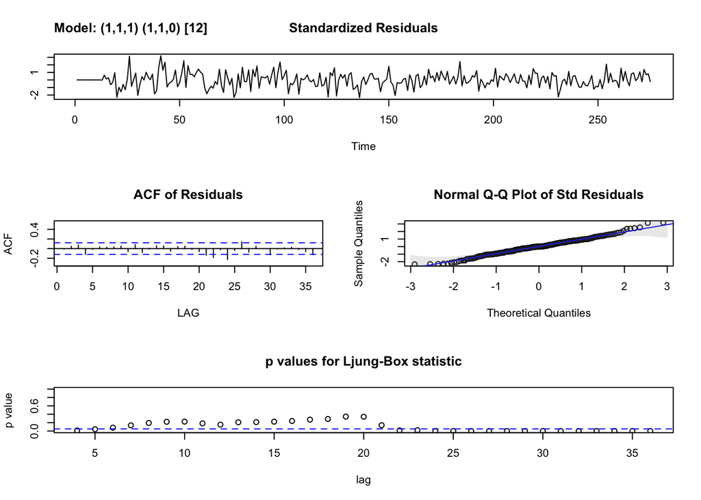

```
## $fit
##
## Call:
## stats::arima(x = xdata, order = c(p, d, q), seasonal = list(order = c(P, D,
##     Q), period = S), include.mean = !no.constant, optim.control = list(trace = trc,
##     REPORT = 1, reltol = tol))
##
## Coefficients:
##          ar1      ma1     sar1
##       0.0978  -1.0000  -0.4526
## s.e.  0.0617   0.0113   0.0555
##
## sigma^2 estimated as 476.6:  log likelihood = -1184.01,  aic = 2376.01
##
## $degrees_of_freedom
## [1] 259
##
## $ttable
##      Estimate     SE  t.value p.value
## ar1    0.0978 0.0617   1.5861  0.1139
## ma1   -1.0000 0.0113 -88.4211  0.0000
## sar1  -0.4526 0.0555  -8.1611  0.0000
##
## $AIC
## [1] 7.188401
##
## $AICc
## [1] 7.196213
##
## $BIC
## [1] 6.227857
```

```r
sarima(Philly_monthly$Pneumonia.and.Influenza.Deaths,1,1,1,1,1,0,12)
```

Using this, we can better forecast future values.

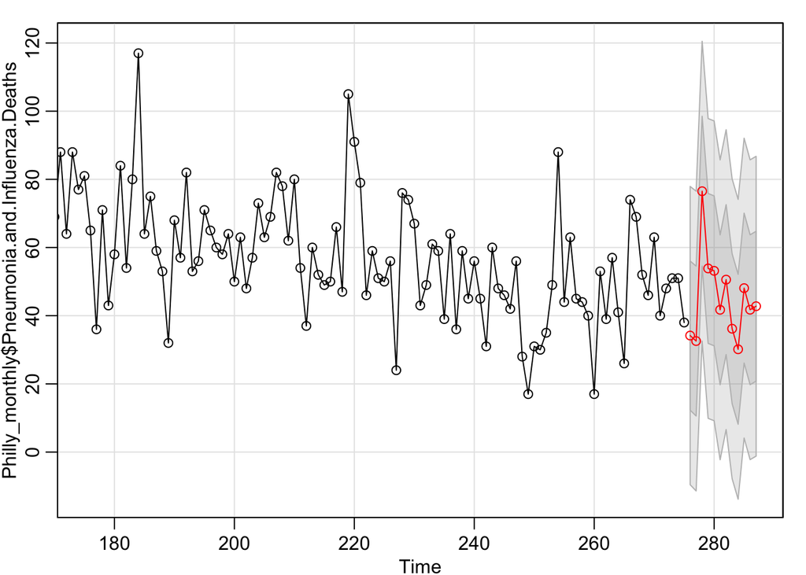

```
## $pred
## Time Series:
## Start = 276
## End = 287
## Frequency = 1
##  [1] 34.17635 32.56396 76.51584 53.86569 53.16069 41.72913 50.58176
##  [8] 36.18176 30.15017 48.08703 41.75018 42.78177
##
## $se
## Time Series:
## Start = 276
## End = 287
## Frequency = 1
##  [1] 21.87278 21.98548 21.98736 21.98746 21.98747 21.98747 21.98747
##  [8] 21.98747 21.98747 21.98747 21.98747 21.98747
```

```r
sarima.for(Philly_monthly$Pneumonia.and.Influenza.Deaths,12,1,1,1,1,1,0,12)
```